# Manuscript table1

Deisiany

2023-09-19

# Table 1

```r
# Load TIR1/AFB1, Aux/IAAs, and ARFs so we can bind all together.
TIR <- read.csv("../final_trees/AFB_input/2023_0919_AFB_Gm_ortholog.csv")


IAA <- read.csv("../final_trees/IAA_input/IAA_Gm_ortholog.csv")
IAA2 <- read.csv("../final_trees/IAA_input/LABELS2_20230917.csv") %>% .[30:90, ]
IAA2 <- IAA2 %>% select(tair_locus, ensembl_gene_id, Class)

IAA_ortho <- merge(IAA, IAA2, by = "tair_locus", all = TRUE)
IAA_ortho <- IAA_ortho %>% rename(`Gene ID` = ensembl_gene_id.x,
                     `Transcript ID` = tair_locus,
                     Orthology = ortholog_name,
                     `Class/Clade` = Class) %>%
  select(`Transcript ID`, Orthology, `Class/Clade`)
IAA_ortho$Family <- "IAA"


expression_data <- read_csv("FINAL_manuscript_gene_INFO.csv")
```

```
## ──────────────────────────────────────────────────────── Delimiter: "," chr
## (6): ensembl_gene_id, ortholog_number, tair_locus, class, name, Family dbl
## (16): AM, OF, IAM, IBM, RootTip, Cotyledon, Hypocotyl, SAM6D, SAM17D, SA...
```

```r
comb_expr_df <- merge(IAA_ortho, expression_data, by.x = "Transcript ID", by.y = "tair_locus", all =TRUE)

comb_expr_df <- comb_expr_df %>% mutate(Class = coalesce(`Class/Clade`, class))

comb_expr_df <- comb_expr_df %>%
  select(-c(class, `Class/Clade`, Orthology, Family.x, `...22`))

# populate NA's in class in accordance to their ensembl gene ID. if the same ID they belong to the same class
comb_expr_df2 <- comb_expr_df %>%
  group_by(ensembl_gene_id) %>%
  mutate(Class = if (all(is.na(Class))) NA else na.omit(Class)) %>%
  ungroup()


# separate Class into Class and Clade
comb_expr_df2 <- comb_expr_df2 %>% separate(Class, c('Class', 'Clade'),sep = " - ")
```

```r
# Now combine TIR df to get their new clades.
df <- merge(comb_expr_df2, TIR, by.x = "ensembl_gene_id", by.y = "ensembl_gene_id", all = TRUE)

df <- df %>% mutate(Clade = coalesce(Clade.x, Clade.y))

df <- df %>% select(-c(Clade.x, Clade.y, class, tair_locus, ortholog_name, name.x, name.y)) %>% rename(Orthology = ortholog_number)

df <- df %>%
  group_by(ensembl_gene_id) %>%
  mutate(Clade = if(all(is.na(Clade))) NA else na.omit(Clade)) %>%
  ungroup()

# I can add clades to ARFs as I have not saved that as csv file when I built trees.
df <- df %>% mutate(Clade = ifelse(grepl("ARF", .$Family.y) & grepl("A", .$Class), "II",
                            ifelse(grepl("ARF", .$Family.y) & grepl("B", .$Class), "I",
                                   ifelse(grepl("ARF", .$Family.y) & grepl("C", .$Class), "III", Clade))))



df2 <-
  df %>% mutate(Class = ifelse(grepl("Glyma.02G218100", .$ensembl_gene_id), "A", Class),
                Clade =
                  ifelse(grepl("Glyma.02G218100", .$ensembl_gene_id), "I", Clade))


df2 <- df2 %>% rename(Family = Family.y, `Gene ID` = ensembl_gene_id) %>% drop_na()

# save Table 1 for manuscript
df2 %>% select(`Gene ID`, Orthology, `Transcript ID`, Class, Clade, Family) %>% arrange(Family, Clade, Class, Orthology) %>% write_csv("Table1.csv")

# write_csv(df2, "20230919_expression_heatmap.csv")
```

# Heatmap

```r
# Source:
# https://stackoverflow.com/questions/43051525/how-to-draw-pheatmap-plot-to-screen-and-also-save-to-file
save_pheatmap_pdf <- function(x, filename, width=7, height=4) {
   stopifnot(!missing(x))
   stopifnot(!missing(filename))
   pdf(filename, width=width, height=height)
   grid::grid.newpage()
   grid::grid.draw(x$gtable)
   dev.off()
}

# https://davetang.org/muse/2018/05/15/making-a-heatmap-in-r-with-the-pheatmap-package/
```

```r
# Make a heatmap label by uniting orthology column and gene ID column
heatmap_df <- df2 %>%
  relocate(`Gene ID`, .after = `Transcript ID`) %>%
  unite("heatmap_label", `Gene ID`:Orthology, sep = "|", remove = TRUE)


# Genes with an average expression across tissues that are less than 2 TPM, will be excluded from downtream analysis
heatmap_df <- heatmap_df %>% filter(Average_Expression > 2) # we kept 150 genes for downstram normalization
```

# Normalization by transcript

```r
Expr_data_Norm <- heatmap_df %>% relocate(c(Class, Clade), .after = Family) %>% select(-Average_Expression)

# Normalize data by performing a z-score transformation on selected columns.

# Iterate through each row of the 'Expr_data_Norm' data frame.
for (j in 1:nrow(Expr_data_Norm)) {
  # Iterate through columns starting from the 6th column to the last column.
for (i in 6:ncol(Expr_data_Norm)) {

  # Calculate the z-score normalization for each cell in the data frame.
    # 1. Subtract the mean of the selected row (columns 6 to the last column).
    # 2. Divide by the standard deviation of the selected row.
  Expr_data_Norm[j,i]<-
    (Expr_data_Norm[j,i]-rowMeans(Expr_data_Norm[j,6:ncol(Expr_data_Norm)]))/
    sd(Expr_data_Norm[j,6:ncol(Expr_data_Norm)])
}
}

Expr_data_Norm <-Expr_data_Norm %>% drop_na() %>% column_to_rownames(., var = "heatmap_label")
```

# Build heatmap with normalized data

```r
# log2 transformation
Expr_data_Norm2 <- log2(Expr_data_Norm[,5:18])
```

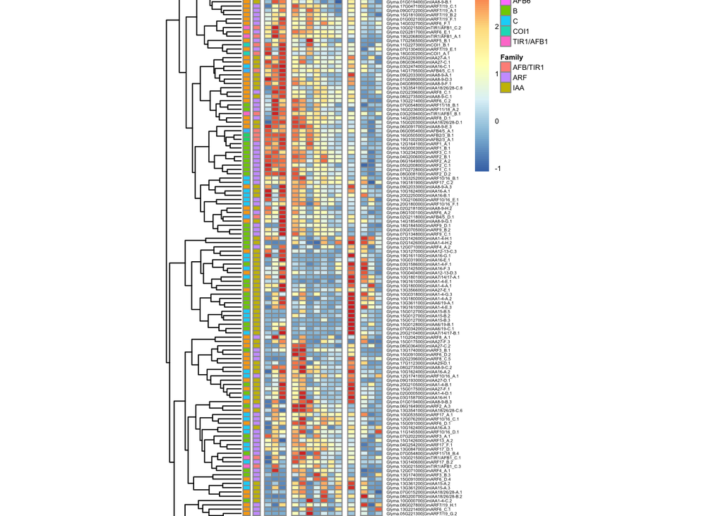

```r
# Minus infinite

# Specify colors
Class_df1_colors = list(Family = c(ARF = "Purple", IAA = "yellow", `AFB/TIR1`="lightblue"), Class = c(A="purple", B="lightseagreen", C="orange", TIR1="green", `AFB2/3`="blue", `AFB4/5`="yellow", COI1="pink", AFB6="pink2", `COI1-A`="pink1", `COI1-A`="pink3"))


pheatmap::pheatmap(mat = Expr_data_Norm[,5:18],  annotation_row = Expr_data_Norm[,c(2,3)],
         fontsize = 5,
         fontsize_row = 3,
         cellwidth = 5,
         cutree_cols = 4,
         cellheight = 3,  na_col = "black",
         clustering_distance_rows = "euclidean",
         main = "Expression analysis")
```

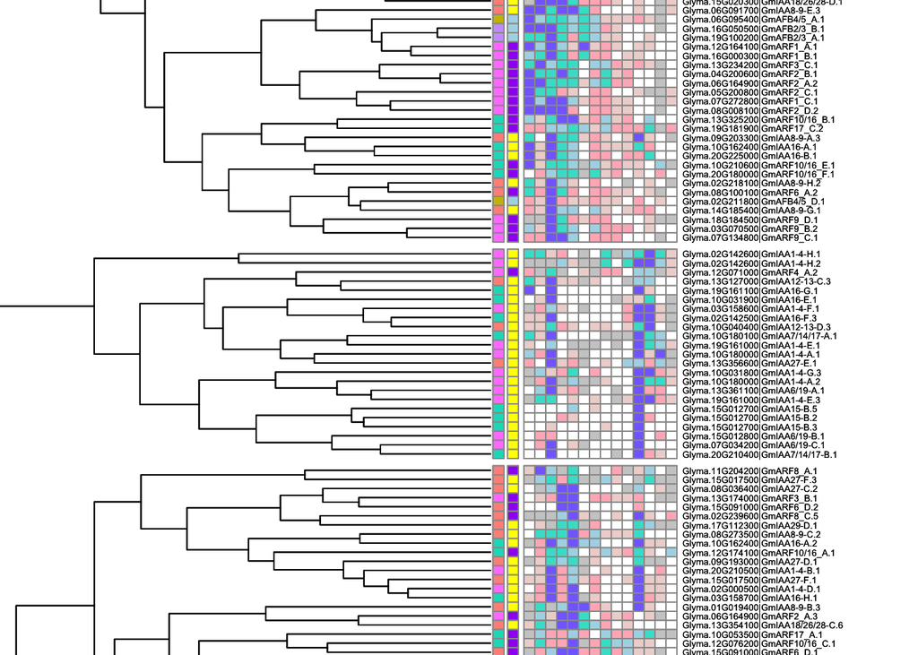

```r
(expr_analysis <- pheatmap::pheatmap(mat = Expr_data_Norm[,5:18],  annotation_row = Expr_data_Norm[,c(2,3)], annotation_colors = Class_df1_colors[1],
         fontsize = 6,
         fontsize_row = 5,
         cellwidth = 6,
         cellheight = 5,
         clustering_distance_rows = "euclidean",
         treeheight_row = 300,
         cutree_rows = 6,
         # main = "Expression analysis - normalized by transcripts",
        color = c("grey80", "white", "mistyrose2", "lightpink", "lightblue", "turquoise", "lightslateblue")))
```

```r
save_pheatmap_pdf(expr_analysis, "20230917_FINAL_NORM_by_Transcript.pdf", height = 12, width = 9)
```

Z-score normalization standardizes the data such that the mean of each row becomes 0 and the standard deviation becomes 1. The resulting values can be positive or negative and represent how many standard deviations a data point is from the mean of its row.

In the context of z-score normalization:

Values close to 0 represent gene expression levels similar to the mean of their respective rows. Negative values represent gene expression levels below the mean of their respective rows. Positive values represent gene expression levels above the mean of their respective rows.

So, in your heatmap, the -1 represents genes that have expression levels approximately 1 standard deviation below the mean of their respective rows.

These genes are relatively lower in expression compared to the mean expression of those genes across the samples or conditions under analysis.

# Principal component analysis

Using the full data set in which data expression was greater than 2. In our PCA we are not using the normalized data. That is beacause we are already transforming our data once by using scale = true, which is known to change the range of the data whereas normalized changes its shape distribution.

Will also remove SAM38D (38 days) from analysis, as we are interested in early development.

```r
pca_data <- heatmap_df %>% relocate(c(Class, Clade), .after = Family) %>% select(-Average_Expression)

# for analysis without tissues that we are not looking at
pca <- prcomp(pca_data[, -c(1:5, 15)],
              scale. = T, center = T)
summary(pca)
```

```
## Importance of components:
##                           PC1    PC2    PC3     PC4     PC5     PC6     PC7
## Standard deviation     2.4582 1.5598 1.2320 0.90464 0.77133 0.66012 0.56141
## Proportion of Variance 0.4648 0.1872 0.1168 0.06295 0.04577 0.03352 0.02424
## Cumulative Proportion  0.4648 0.6520 0.7687 0.83166 0.87743 0.91095 0.93519
##                            PC8     PC9    PC10    PC11    PC12    PC13
## Standard deviation     0.52720 0.45090 0.38559 0.33545 0.23198 0.21502
## Proportion of Variance 0.02138 0.01564 0.01144 0.00866 0.00414 0.00356
## Cumulative Proportion  0.95657 0.97221 0.98365 0.99230 0.99644 1.00000
```

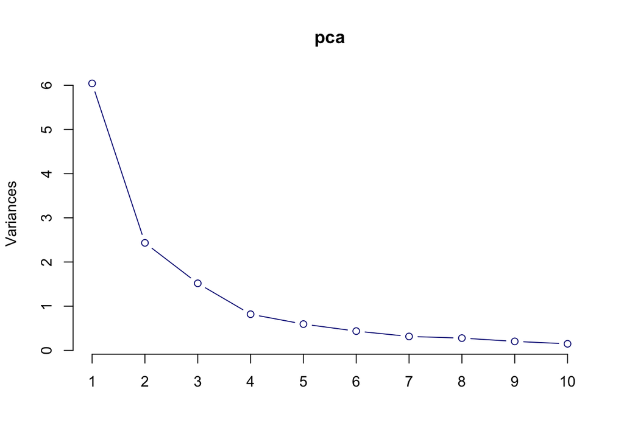

```r
plot(pca, type="l", col="navy")
```

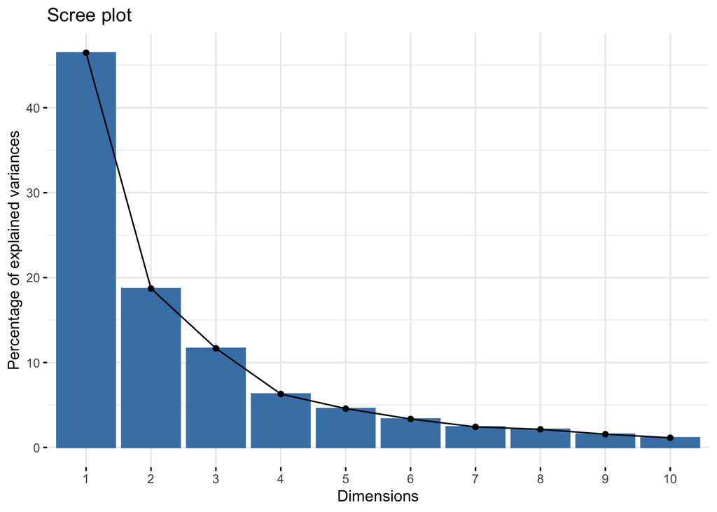

```r
factoextra::fviz_eig(pca)
```

```r
Family <- df$Family
```

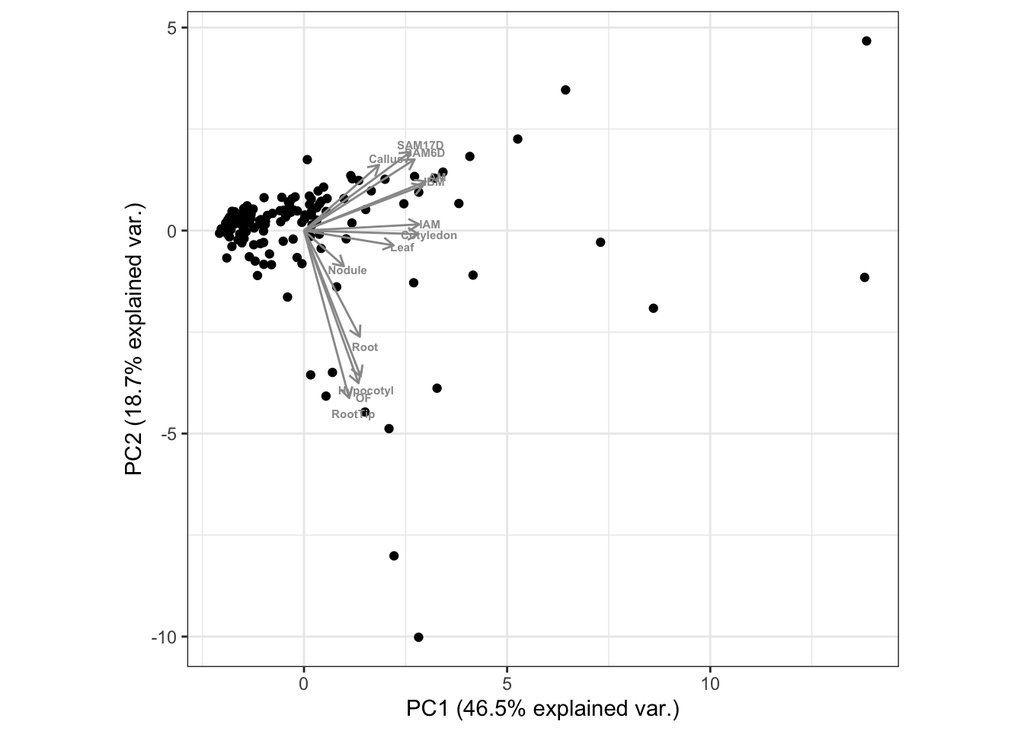

```r
# extract the loading so we can change the arrows more easily
PCA_loadings <- data.frame(Variables=rownames(pca$rotation), pca$rotation)


ggbiplot::ggbiplot(pca, obs.scale = 1, var.scale = .5,
                             varname.adjust = 3,
                            groups = Family, var.axes = F, varname.size = 2,
                  ellipse = TRUE,  circle = FALSE, ellipse.prob = .70) +
    geom_segment(PCA_loadings, mapping=aes(x=0, y=0, # Change the size of arrows
                                           xend=(PC1*8), yend=(PC2*8)),
                 arrow = arrow(length = unit(1/2, "picas")), color="gray60") +
    annotate("text", x=(PCA_loadings$PC1*8.75), #add the tissue names to it manually
             y=(PCA_loadings$PC2*8.75),
             label=PCA_loadings$Variables, size=2, color="gray60", fontface="bold") +
    theme(panel.background = element_rect(fill = "white", linewidth = 1))+
    theme_bw()+
   scale_color_manual(values=c("#86C5D8", "#620093", "#E7C94C"))
```

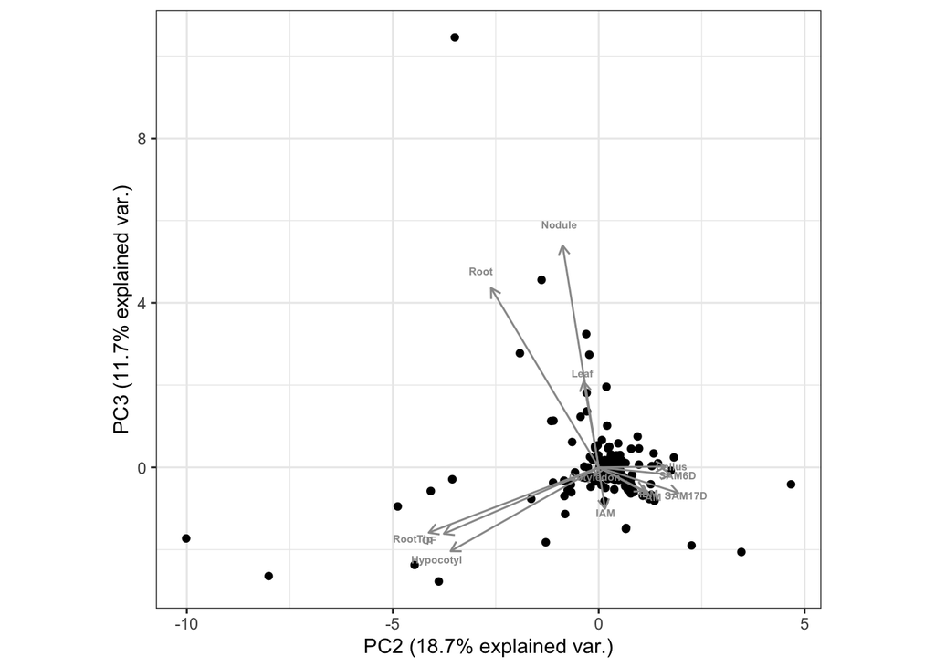

```r
ggbiplot::ggbiplot(pca, obs.scale = 1, var.scale = .5, choices = c(2, 3),
                             varname.adjust = 3,
                            groups = Family, var.axes = F, varname.size = 2,
                  ellipse = TRUE,  circle = FALSE, ellipse.prob = .70) +
    geom_segment(PCA_loadings, mapping=aes(x=0, y=0, # Change the size of arrows
                                           xend=(PC2*8), yend=(PC3*8)),
                 arrow = arrow(length = unit(1/2, "picas")), color="gray60") +
    annotate("text", x=(PCA_loadings$PC2*8.75), #add the tissue names to it manually
             y=(PCA_loadings$PC3*8.75),
             label=PCA_loadings$Variables, size=2, color="gray60", fontface="bold") +
    theme(panel.background = element_rect(fill = "white", linewidth = 1))+
    theme_bw()+
   scale_color_manual(values=c("#86C5D8", "#620093", "#E7C94C"))
```

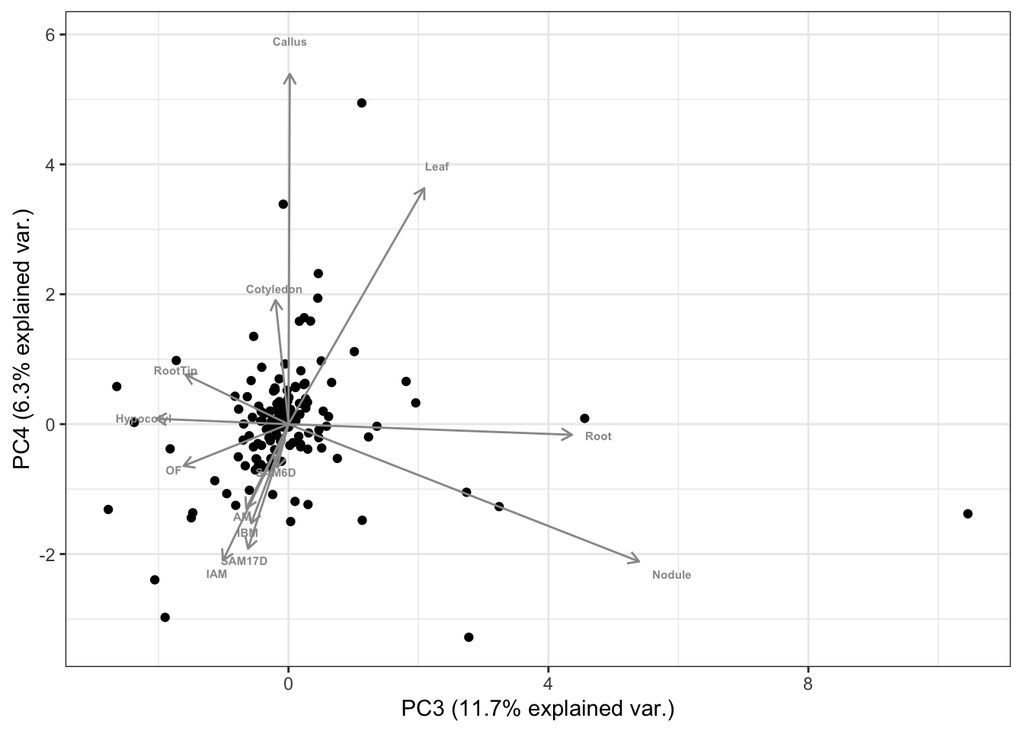

```r
ggbiplot::ggbiplot(pca, obs.scale = 1, var.scale = .5, choices = c(3,4),
                             varname.adjust = 3,
                            groups = Family, var.axes = F, varname.size = 2,
                  ellipse = TRUE,  circle = FALSE, ellipse.prob = .70) +
    geom_segment(PCA_loadings, mapping=aes(x=0, y=0, # Change the size of arrows
                                           xend=(PC3*8), yend=(PC4*8)),
                 arrow = arrow(length = unit(1/2, "picas")), color="gray60") +
    annotate("text", x=(PCA_loadings$PC3*8.75), #add the tissue names to it manually
             y=(PCA_loadings$PC4*8.75),
             label=PCA_loadings$Variables, size=2, color="gray60", fontface="bold") +
    theme(panel.background = element_rect(fill = "white", linewidth = 1))+
    theme_bw()+
   scale_color_manual(values=c("#86C5D8", "#620093", "#E7C94C"))
```

# PCA with only tissues of interest

```r
pca2 <- prcomp(pca_data[, -c(1:5, 7:10, 15:16, 18:19)],
              scale. = T, center = T)
summary(pca2)
```

```
## Importance of components:
##                           PC1    PC2    PC3     PC4     PC5     PC6
## Standard deviation     1.9444 1.0099 0.8460 0.49381 0.38274 0.30563
## Proportion of Variance 0.6301 0.1700 0.1193 0.04064 0.02441 0.01557
## Cumulative Proportion  0.6301 0.8001 0.9194 0.96002 0.98443 1.00000
```

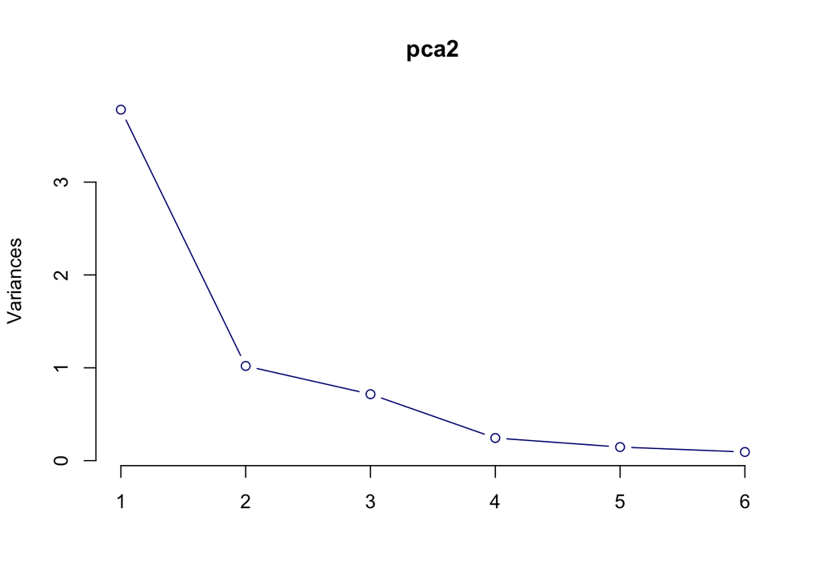

```r
plot(pca2, type="l", col="navy")
```

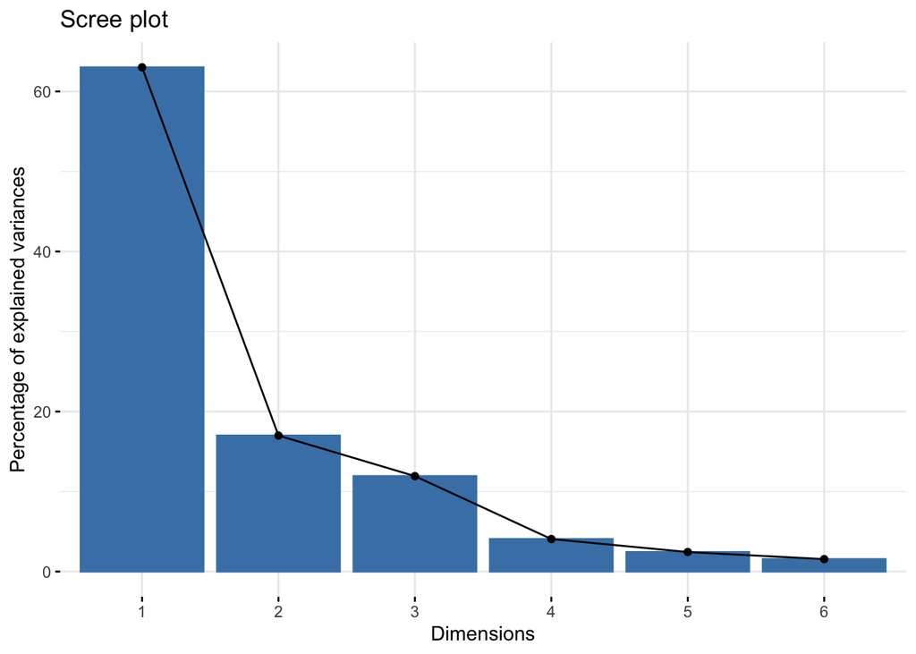

```r
factoextra::fviz_eig(pca2)
```

```r
df2 <- cbind(pca_data, pca2$x[, 1:4])
head(df2)
```

```
##       Transcript ID                 heatmap_label Family Class Clade        AM
## 1 Glyma.01G002100.1 Glyma.01G002100|GmARF7/19_F.1    ARF     A    II 10.166688
## 2 Glyma.01G019400.1  Glyma.01G019400|GmIAA8-9-B.1    IAA     A     I  4.023220
## 3 Glyma.01G019400.2  Glyma.01G019400|GmIAA8-9-B.2    IAA     A     I  3.945653
## 4 Glyma.01G019400.3  Glyma.01G019400|GmIAA8-9-B.3    IAA     A     I 22.514233
## 5 Glyma.01G098000.3  Glyma.01G098000|GmIAA8-9-D.3    IAA     A     I 68.216252
## 6 Glyma.01G103500.1    Glyma.01G103500|GmARF9_A.1    ARF     B     I 23.365836
##          OF       IAM       IBM   RootTip Cotyledon  Hypocotyl      SAM6D
## 1 11.093702  9.940766 11.778406  6.055558  6.293037  12.466244   8.948254
## 2  7.572444  0.000000  1.479181  3.679860  1.003818   8.866408   2.983280
## 3  0.000000  6.009114  7.650699  2.217478  2.098637  11.260883   9.399142
## 4 35.850834 20.735453 26.681081 16.122488  4.029864  88.717989  25.081359
## 5 51.350688 53.553189 96.275020 32.628226 78.301786 172.112449 101.538840
## 6  7.195187 14.135920 28.240802  4.918282  2.088168   2.353419  26.594544
##       SAM17D    SAM38D    Callus      Leaf      Root    Nodule         PC1
## 1   8.096833  5.745906  9.251965  4.882454  6.893253  1.926212 -0.81566833
## 2   7.873006  3.443632  6.039812 10.540945  5.246408  0.577947 -1.10529800
## 3   0.000000  2.491927  0.946290 11.828802 22.566715  1.890763 -1.00874467
## 4  26.514627 29.093086 17.719987  6.167892  0.000000  0.000000  0.03540281
## 5 108.035003 57.568952  3.602672 72.181052 53.728970 22.341412  6.61003261
## 6  33.652046 16.405528  1.091669  0.000000  0.000000  0.000000 -0.22293748
##            PC2        PC3         PC4
## 1  0.110333618  0.1054437 -0.16308499
## 2  0.050130407  0.4101916  0.02512164
## 3 -0.001094378  0.4728579 -0.05095923
## 4 -0.349112816 -0.5187677  0.39220427
## 5 -1.458712160  1.3627995 -1.11936751
## 6  0.744262807 -0.4026389  0.23004698
```

```r
Family <- df2$Family
```

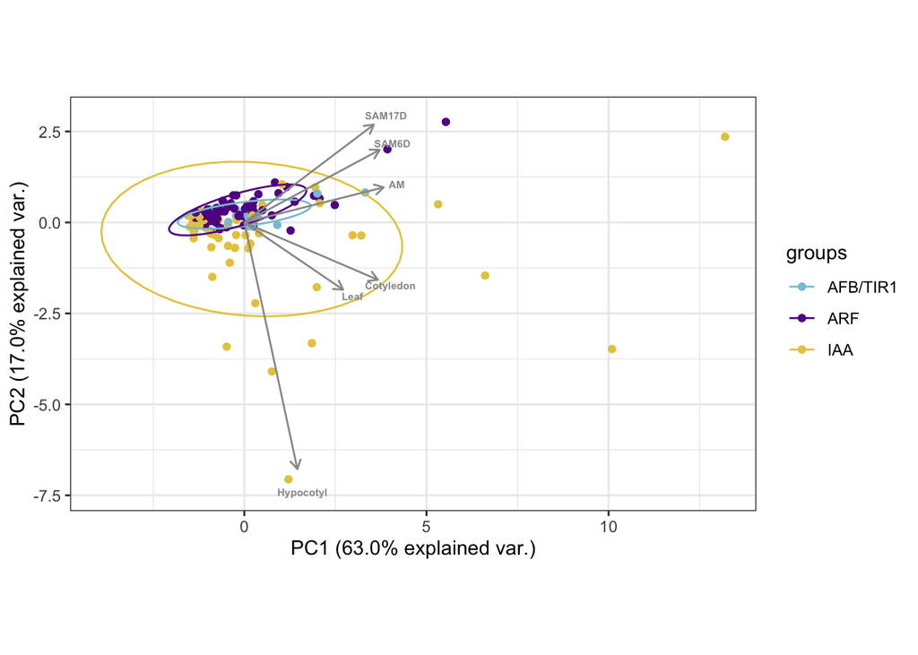

```r
# extract the loading so we can change the arrows more easily
PCA_loadings2 <- data.frame(Variables=rownames(pca2$rotation), pca2$rotation)


ggbiplot::ggbiplot(pca2, obs.scale = 1, var.scale = .5, choices = c(1, 2),
                             varname.adjust = 3,
                            groups = Family, var.axes = F, varname.size = 2,
                  ellipse = TRUE,  circle = FALSE, ellipse.prob = .70) +
    geom_segment(PCA_loadings2, mapping=aes(x=0, y=0, # Change the size of arrows
                                           xend=(PC1*8), yend=(PC2*8)),
                 arrow = arrow(length = unit(1/2, "picas")), color="gray60") +
    annotate("text", x=(PCA_loadings2$PC1*8.75), #add the tissue names to it manually
             y=(PCA_loadings2$PC2*8.75),
             label=PCA_loadings2$Variables, size=2, color="gray60", fontface="bold") +
    theme(panel.background = element_rect(fill = "white", linewidth = 1))+
    theme_bw()+
   scale_color_manual(values=c("#86C5D8", "#620093", "#E7C94C"))
```

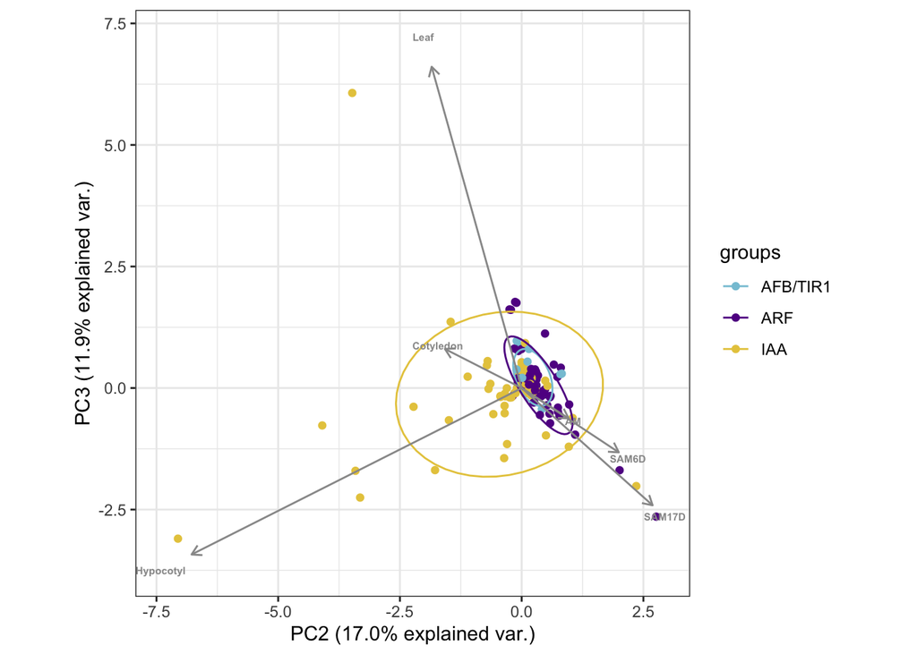

```r
ggbiplot::ggbiplot(pca2, obs.scale = 1, var.scale = .5, choices = c(2, 3),
                             varname.adjust = 3,
                            groups = Family, var.axes = F, varname.size = 2,
                  ellipse = TRUE,  circle = FALSE, ellipse.prob = .70) +
    geom_segment(PCA_loadings2, mapping=aes(x=0, y=0, # Change the size of arrows
                                           xend=(PC2*8), yend=(PC3*8)),
                 arrow = arrow(length = unit(1/2, "picas")), color="gray60") +
    annotate("text", x=(PCA_loadings2$PC2*8.75), #add the tissue names to it manually
             y=(PCA_loadings2$PC3*8.75),
             label=PCA_loadings2$Variables, size=2, color="gray60", fontface="bold") +
    theme(panel.background = element_rect(fill = "white", linewidth = 1))+
    theme_bw()+
   scale_color_manual(values=c("#86C5D8", "#620093", "#E7C94C"))
```

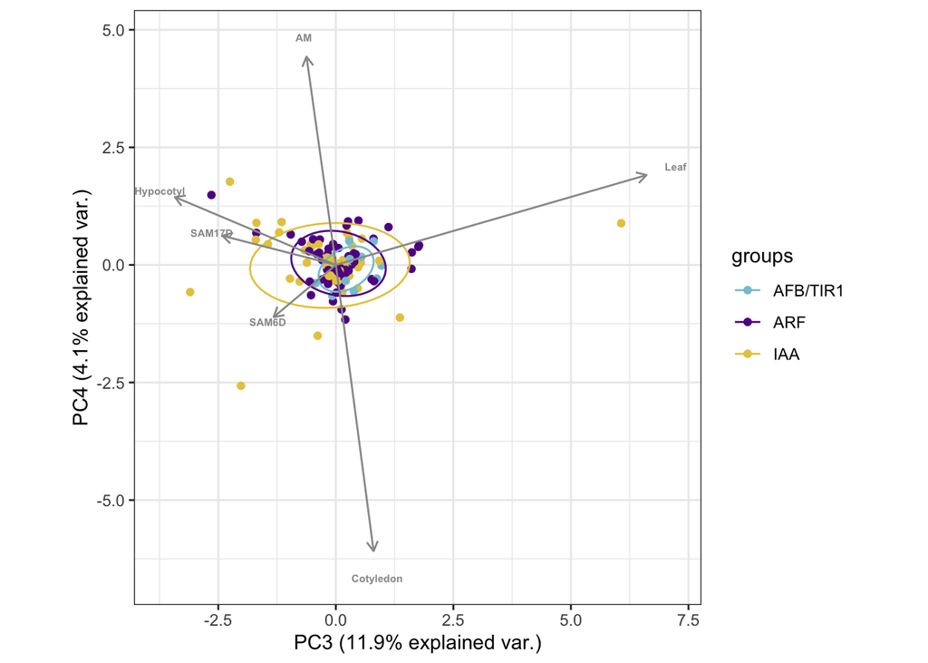

```r
ggbiplot::ggbiplot(pca2, obs.scale = 1, var.scale = .5, choices = c(3,4),
                             varname.adjust = 3,
                            groups = Family, var.axes = F, varname.size = 2,
                  ellipse = TRUE,  circle = FALSE, ellipse.prob = .70) +
    geom_segment(PCA_loadings2, mapping=aes(x=0, y=0, # Change the size of arrows
                                           xend=(PC3*8), yend=(PC4*8)),
                 arrow = arrow(length = unit(1/2, "picas")), color="gray60") +
    annotate("text", x=(PCA_loadings2$PC3*8.75), #add the tissue names to it manually
             y=(PCA_loadings2$PC4*8.75),
             label=PCA_loadings2$Variables, size=2, color="gray60", fontface="bold") +
    theme(panel.background = element_rect(fill = "white", linewidth = 1))+
    theme_bw()+
   scale_color_manual(values=c("#86C5D8", "#620093", "#E7C94C"))
```